# IST 687 Project - Traffic Collision Data Analysis

Veasna Oum

## Traffic Collision Data Analysis

My work consists of two sections:

1. An analysis of demographics collisions by year of: age(min, max, avg), gender and background stats in R pulled from SQL Server.
2. Time Series Forecast system to look into high collisions areas that might be of interest to reduce traffic accidents via law enforcement, additional traffic controller or other means mitigating the situation

## Installing packages, creating the sql connection within R and ODBC and creating a basic select statement from SQL to test the connection

```r
#install.packages("sqldf")
#Install.packages(“RODBC“)
#install.packages("aplpack")
#install.packages("fpp2")
#install.packages("xts")

#dir <- "~/rstudio-pandoc"

    ## The version of Pandoc to be installed.
    #version <- "2.7.1"

    ## Create and move to the requested directory.
    #dir.create(dir, showWarnings = FALSE, recursive = TRUE)
    #owd <- setwd(dir)
    #on.exit(setwd(owd), add = TRUE)

    ## Construct path to pandoc.
    #root <- "https://s3.amazonaws.com/rstudio-buildtools"
    #suffix <- sprintf("pandoc-%s-windows-x86_64.zip", version)
    #url <- file.path(root, "pandoc-rstudio", version, suffix)

    ## Download and extract pandoc.
    #file <- basename(url)
    #utils::download.file(url, destfile = file)
    #utils::unzip(file)
    #unlink(file)

    ## Write .Renviron to update the version of Pandoc used.
    #entry <- paste("RSTUDIO_PANDOC", shQuote(path.expand(dir)), sep = " = ")
    #contents <- if (file.exists("~/.Renviron")) readLines("~/.Renviron")
    #filtered <- grep("^RSTUDIO_PANDOC", contents, value = TRUE, invert = TRUE)
    #amended <- union(filtered, entry)
    #writeLines(amended, "~/.Renviron")

    ## Report change to the user.
    #writeLines("Updated .Renviron:\n")
    #writeLines(amended)
    #writeLines("\nPlease restart RStudio for these changes to take effect.")

library("sqldf")
library("RODBC")
library("aplpack")
library("fpp2")
library("ggplot2")
library("xts")
library("reshape2")

#rm(list = ls())

con <- odbcConnect("Traffic Collision Data", uid = "supersql", pwd = "Admin12#")

#Looking at the youngest, oldest and average age across the board

SqlStatement <- sqlQuery(con,'SELECT MIN(VictimAge) AS YoungestAge
        , MAX(VictimAge) AS OldestAge
        , AVG(VictimAge) AS AverageAge
    FROM dbo.TCD
    WHERE VictimAge <> 0')

SqlStatement
```

```
##   YoungestAge OldestAge AverageAge
## 1          10        99         41
```

## Demographics Analysis System

This is a table displaying the victim of the youngest, oldest, average age by gender and descent from 2010 to 2019. To improve processing, R will run SQL statement from the year 2017 and forward.

```r
dir.create("C:/Users/veo78/AppData/Local/RStudio-Desktop/notebooks/A268F4D5-Traffic Collision Data/1/49AF9CB4C0E46D42/c9kqlim0gls5c_t")
```

```r
save(iris, file=file.path("C:/Users/veo78/AppData/Local/RStudio-Desktop/notebooks/A268F4D5-Traffic Collision Data/1/49AF9CB4C0E46D42/c9kqlim0gls5c_t","_rs_rdf_14c07d5b2025.rdf"))

#con <- odbcConnect("Traffic Collision Data", uid="supersql",pwd="Admin12#")

SqlStatement2 <- sqlQuery(con,'SELECT
        YEARDateOccurred
        , VictimSex
        , VictimDescent
        , MIN(VictimAge) AS YoungestAge
        , MAX(VictimAge) AS OldestAge
        , AVG(VictimAge) AS AverageAge
    FROM (
        SELECT
            YEAR(DateOccurred) AS YEARDateOccurred
            , VictimSex
            , VictimDescent
            , VictimAge
        FROM dbo.TCD

        ) a
    WHERE YEARDateOccurred >= 2017
    GROUP BY
        YEARDateOccurred
        , VictimSex
        , VictimDescent
    HAVING MIN(VictimAge) > 0
    ORDER BY YEARDateOccurred, VictimSex')

SqlStatement2
```

```
##    YEARDateOccurred VictimSex VictimDescent YoungestAge OldestAge
## 1              2017         F             L          41        41
## 2              2017         F             G          24        37
## 3              2017         F             C          20        72
## 4              2017         F             V          22        64
## 5              2017         F             S          20        49
## 6              2017         F             D          54        54
## 7              2017         H             F          40        40
## 8              2017         H             H          38        38
## 9              2017         H             A          36        36
## 10             2017         H             B          25        73
## 11             2017         M             J          24        83
## 12             2017         M             D          28        55
## 13             2017         M             S          33        50
## 14             2017         M             I          23        65
```

[output cut: 109 more lines]

## Time Series Analysis

Most of the heavy lifting of the data were done in the backend; R was used to calculate the frontend of the Time Series Prediction.

This next SQL select statement is the dataset for the Time Series Analysis

Taking a look at the distribution and median of accidents

Boxplot analyis will determined which subset to investigate

Bagplot analysis shows points of where the majority of the frequency of collisions vs the collisions outliers

```r
#con <- odbcConnect("Traffic Collision Data", uid = "supersql", pwd = "Admin12#")

SqlStatement3 <- sqlQuery(con,'SELECT
        [Address]
        , YEAR(DateOccurred) AS YEAROccurred
        , SUM(Collisions) AS Collisions
    FROM dbo.CollisionTimeSeriesAnalysis2
    WHERE YEAR(DateOccurred) >= 2017
    GROUP BY [Address], DateOccurred
    ORDER BY Collisions DESC--, DateOccurred')

#SqlStatement3

tapply(SqlStatement3$Collisions, SqlStatement3$YEAROccurred, mean)
```

```
##     2017     2018     2019
## 7.986348 7.916339 7.951817
```

```r
tapply(SqlStatement3$Collisions, SqlStatement3$YEAROccurred, median)
```

```
## 2017 2018 2019
##    3    3    3
```

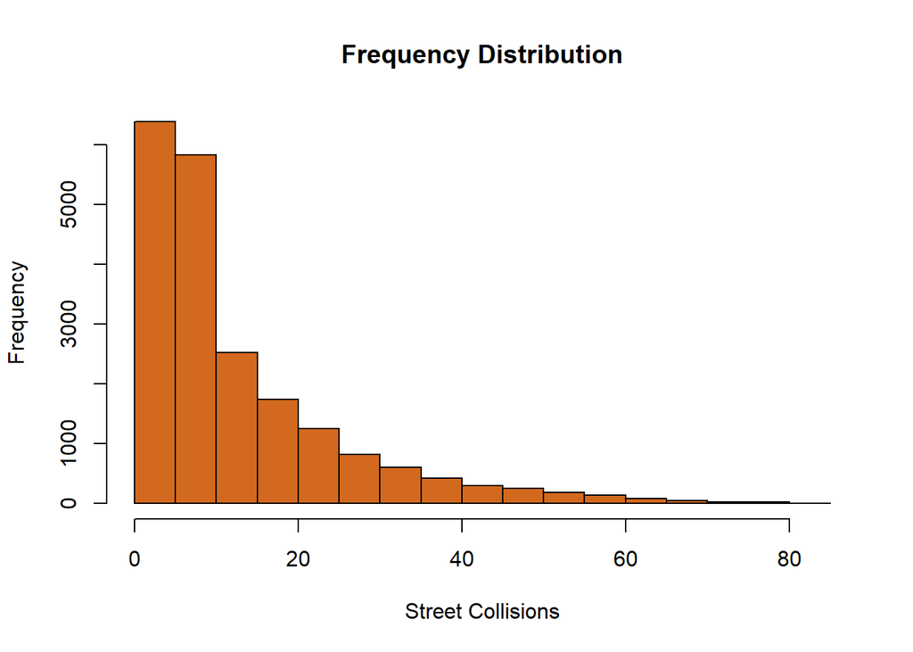

```r
SqlStatement4 <- sqlQuery(con,'SELECT Collisions
    FROM(
        SELECT
            [Address]
            , YEAR(DateOccurred) AS YEAROccurred
            , SUM(Collisions) AS Collisions
        FROM dbo.CollisionTimeSeriesAnalysis2
        WHERE Collisions > 3
        GROUP BY [Address], DateOccurred
        --ORDER BY Collisions DESC--, DateOccurred
        ) a ORDER BY Collisions DESC')

SqlStatement4 <- suppressWarnings(as.numeric(unlist(SqlStatement4)))

#hist(SqlStatement4)
hist(SqlStatement4,
main = "Frequency Distribution",
xlab = "Street Collisions",

col = "chocolate",
border = "black",
breaks = 16
)
```

```r
median(SqlStatement4)
```

```
## [1] 8
```

```r
mean(SqlStatement4)
```

```
## [1] 13.48038
```

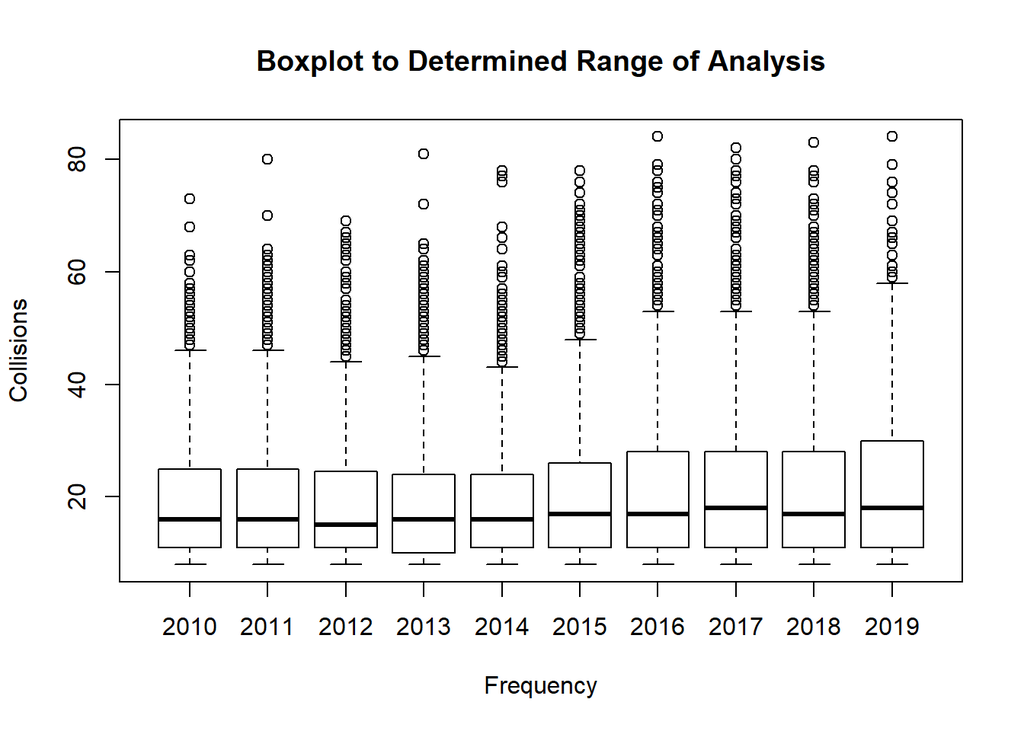

```r
#Boxplot of collision by Addresses

SqlStatement5 <- sqlQuery(con, 'SELECT * FROM dbo.Bagplot WHERE Collisions >= 8 ORDER BY [Address], YEAROccurred')
#SqlStatement5

#SqlStatement5 <- as.numeric(unlist(SqlStatement5))

boxplot(Collisions~YEAROccurred, data = SqlStatement5, main = "Boxplot to Determined Range of Analysis",
   xlab = "Frequency", ylab = "Collisions")
```

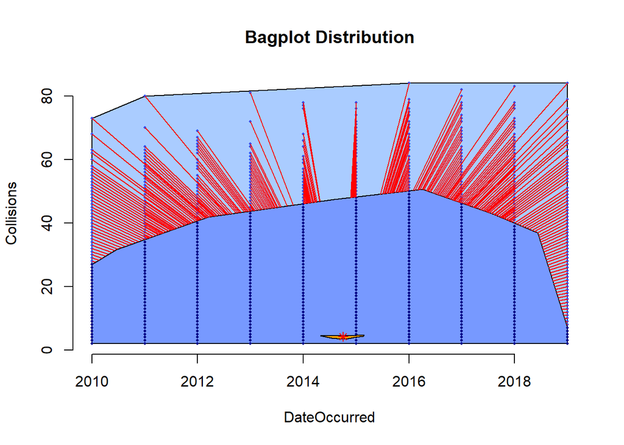

```r
SqlStatement6 <- sqlQuery(con,'SELECT * FROM dbo.Bagplot')
 # SqlStatement6

attach(SqlStatement6)

bagplot(YEAROccurred, Collisions, xlab = "DateOccurred", ylab = "Collisions",
  main = "Bagplot Distribution")
```

## Time Series Analysis Continues

From the previous boxplots & bagplot analysis, I want to investigate all addresses that had a collisions 4th quartile range

The time series will predict future trends of collisions

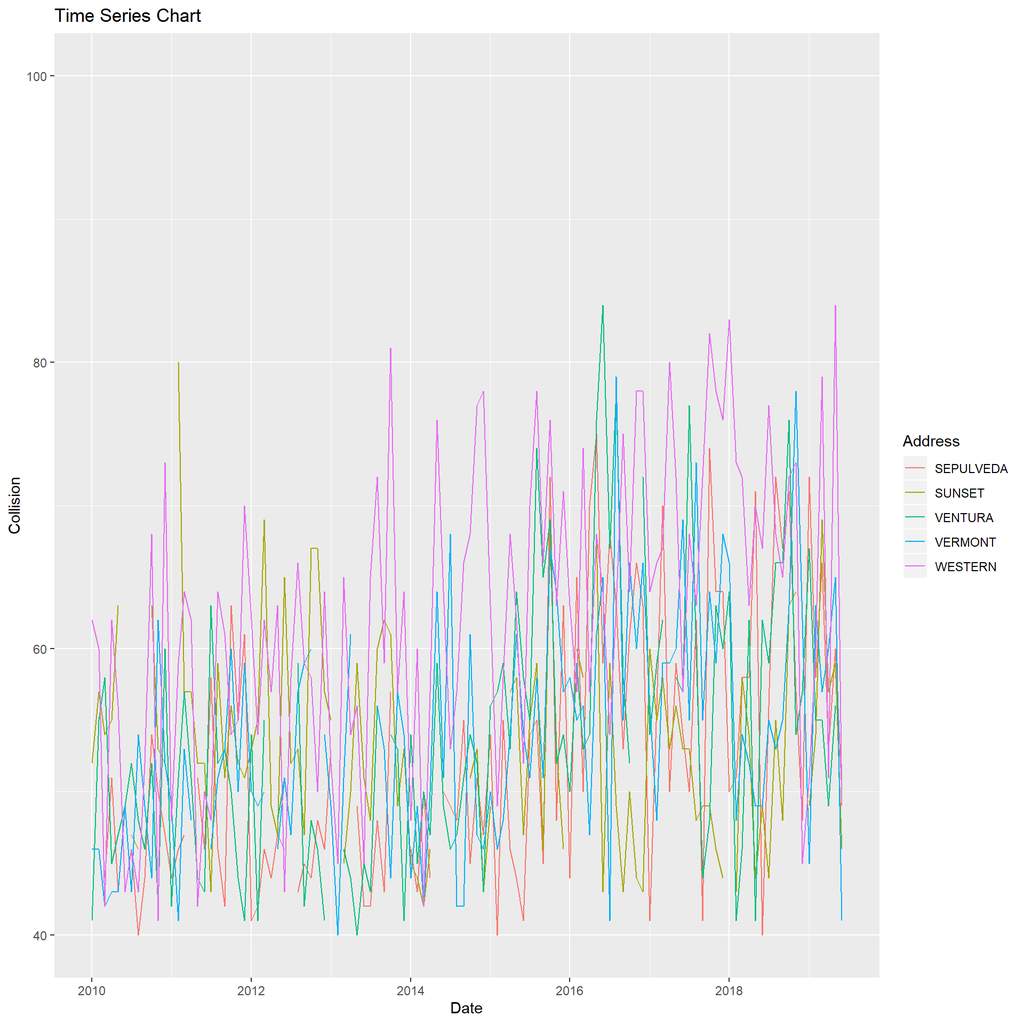

```r
#con <- odbcConnect("Traffic Collision Data", uid = "supersql", pwd = "Admin12#")

#ThisTHIS QUERY TO ANALYZE WHICH STREET TO FURTHER TRAFFIC CONTROL

    #SELECT
        #[Address]
        #--, YEAR(DateOccurred) AS YEAROccurred
        #, SUM(Collisions) AS Collisions
  #FROM dbo.CollisionTimeSeriesAnalysis2
    #--WHERE Collisions > 3
    #GROUP BY [Address] --, DateOccurred
    #ORDER BY Collisions DESC--, DateOccurred

SqlStatement7 <- sqlQuery(con,'SELECT * FROM dbo.Bagplot_Address')

ts <- data.frame(as.Date(SqlStatement7$DateOccurred), SqlStatement7$Address, SqlStatement7$Collisions)

names(ts)[1] <- "Date"
names(ts)[2] <- "Address"
names(ts)[3] <- "Collision"

#Y <- ts(SqlStatement7[,2], start = c(2010, 1), frequency = 12)

#Time Plot - THIS NOT IN USE

#autoplot(Y) + ggtitle("Time Plot: Collision by Month") + ylab("Blah")


TimeLine <- ggplot(ts, aes(x = Date, y = Collision, color = Address))
TimeLine <- TimeLine + geom_line() #+ coord_fixed(ratio = 2)
TimeLine <- TimeLine + ylim(40, 100)
TimeLine <- TimeLine + ggtitle("Time Series Chart")
TimeLine
```

## Time Series Prediction

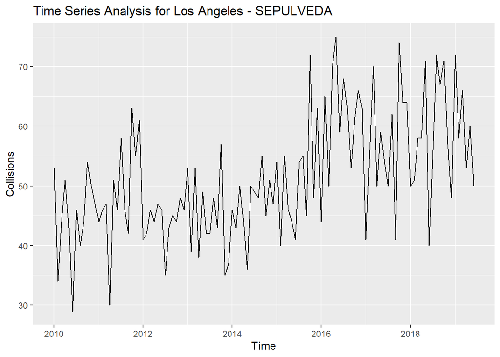

```r
#con <- odbcConnect("Traffic Collision Data", uid = "supersql", pwd = "Admin12#")

SqlStatement7 <- sqlQuery(con, 'SELECT * FROM dbo.SEPULVEDA')
#SqlStatement7

timeplot1 <- ts(SqlStatement7[, 2], start = c(2010, 1), frequency = 12)
#timeplot1

autoplot(timeplot1) + ggtitle("Time Series Analysis for Los Angeles - SEPULVEDA") + ylab("Collisions")
```

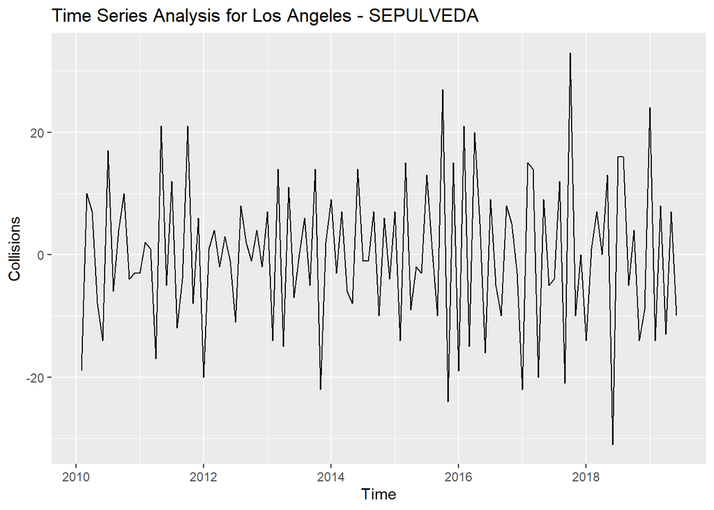

```r
dy <- diff(timeplot1)

autoplot(dy) + ggtitle("Time Series Analysis for Los Angeles - SEPULVEDA") + ylab("Collisions")
```

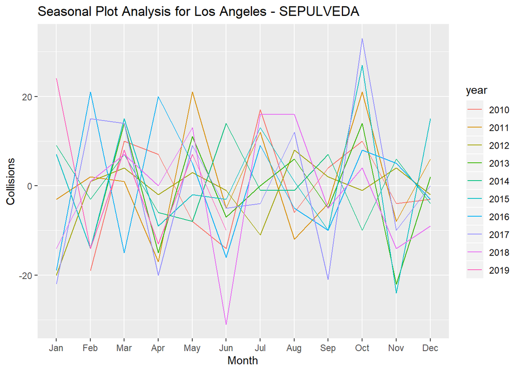

```r
ggseasonplot(dy) + ggtitle("Seasonal Plot Analysis for Los Angeles - SEPULVEDA") + ylab("Collisions")
```

```r
#Fit ARIMA Model
#Take out trends and Seasonality
#Stepwise - test all model
#Approx
#trace - print out the model

Collision_Rate <- timeplot1

fit_arima <- auto.arima(Collision_Rate, d = 1, D = 1, stepwise = FALSE, approximation = FALSE, trace = TRUE)
```

```
##
##  ARIMA(0,1,0)(0,1,0)[12]                    : 858.2536
##  ARIMA(0,1,0)(0,1,1)[12]                    : Inf
##  ARIMA(0,1,0)(0,1,2)[12]                    : Inf
##  ARIMA(0,1,0)(1,1,0)[12]                    : 814.9149
##  ARIMA(0,1,0)(1,1,1)[12]                    : Inf
##  ARIMA(0,1,0)(1,1,2)[12]                    : Inf
##  ARIMA(0,1,0)(2,1,0)[12]                    : 816.9971
##  ARIMA(0,1,0)(2,1,1)[12]                    : Inf
##  ARIMA(0,1,0)(2,1,2)[12]                    : Inf
##  ARIMA(0,1,1)(0,1,0)[12]                    : Inf
##  ARIMA(0,1,1)(0,1,1)[12]                    : Inf
##  ARIMA(0,1,1)(0,1,2)[12]                    : Inf
##  ARIMA(0,1,1)(1,1,0)[12]                    : 758.3659
##  ARIMA(0,1,1)(1,1,1)[12]                    : Inf
##  ARIMA(0,1,1)(1,1,2)[12]                    : Inf
##  ARIMA(0,1,1)(2,1,0)[12]                    : 758.5796
##  ARIMA(0,1,1)(2,1,1)[12]                    : Inf
##  ARIMA(0,1,1)(2,1,2)[12]                    : Inf
##  ARIMA(0,1,2)(0,1,0)[12]                    : 791.9511
##  ARIMA(0,1,2)(0,1,1)[12]                    : Inf
##  ARIMA(0,1,2)(0,1,2)[12]                    : Inf
##  ARIMA(0,1,2)(1,1,0)[12]                    : 760.0676
##  ARIMA(0,1,2)(1,1,1)[12]                    : Inf
##  ARIMA(0,1,2)(1,1,2)[12]                    : Inf
##  ARIMA(0,1,2)(2,1,0)[12]                    : 759.451
##  ARIMA(0,1,2)(2,1,1)[12]                    : Inf
##  ARIMA(0,1,3)(0,1,0)[12]                    : Inf
##  ARIMA(0,1,3)(0,1,1)[12]                    : Inf
##  ARIMA(0,1,3)(0,1,2)[12]                    : Inf
##  ARIMA(0,1,3)(1,1,0)[12]                    : 761.58
##  ARIMA(0,1,3)(1,1,1)[12]                    : Inf
##  ARIMA(0,1,3)(2,1,0)[12]                    : 761.1373
##  ARIMA(0,1,4)(0,1,0)[12]                    : 794.1856
##  ARIMA(0,1,4)(0,1,1)[12]                    : Inf
##  ARIMA(0,1,4)(1,1,0)[12]                    : 763.4458
##  ARIMA(0,1,5)(0,1,0)[12]                    : Inf
##  ARIMA(1,1,0)(0,1,0)[12]                    : 814.5819
##  ARIMA(1,1,0)(0,1,1)[12]                    : Inf
##  ARIMA(1,1,0)(0,1,2)[12]                    : Inf
```

[output cut: 46 more lines]

```
##  ARIMA(3,1,0)(1,1,1)[12]                    : Inf
##  ARIMA(3,1,0)(2,1,0)[12]                    : 770.1735
##  ARIMA(3,1,1)(0,1,0)[12]                    : 792.5723
##  ARIMA(3,1,1)(0,1,1)[12]                    : Inf
##  ARIMA(3,1,1)(1,1,0)[12]                    : 762.2788
##  ARIMA(3,1,2)(0,1,0)[12]                    : 794.6874
##  ARIMA(4,1,0)(0,1,0)[12]                    : 792.6565
##  ARIMA(4,1,0)(0,1,1)[12]                    : Inf
##  ARIMA(4,1,0)(1,1,0)[12]                    : 763.1275
##  ARIMA(4,1,1)(0,1,0)[12]                    : 794.493
##  ARIMA(5,1,0)(0,1,0)[12]                    : 794.6948
##
##
##
##  Best model: ARIMA(0,1,1)(1,1,0)[12]
```

```r
print(summary(fit_arima))
```

```
## Series: Collision_Rate
## ARIMA(0,1,1)(1,1,0)[12]
##
## Coefficients:
##           ma1     sar1
##       -0.8557  -0.5843
## s.e.   0.0568   0.0835
##
## sigma^2 estimated as 96.01:  log likelihood=-376.06
## AIC=758.12   AICc=758.37   BIC=765.96
##
## Training set error measures:
##                     ME     RMSE      MAE       MPE     MAPE      MASE
## Training set 0.1483408 9.131218 6.535942 -1.589555 13.10852 0.6795781
##                     ACF1
## Training set -0.06293731
##                     ME     RMSE      MAE       MPE     MAPE      MASE
## Training set 0.1483408 9.131218 6.535942 -1.589555 13.10852 0.6795781
##                     ACF1
## Training set -0.06293731
```

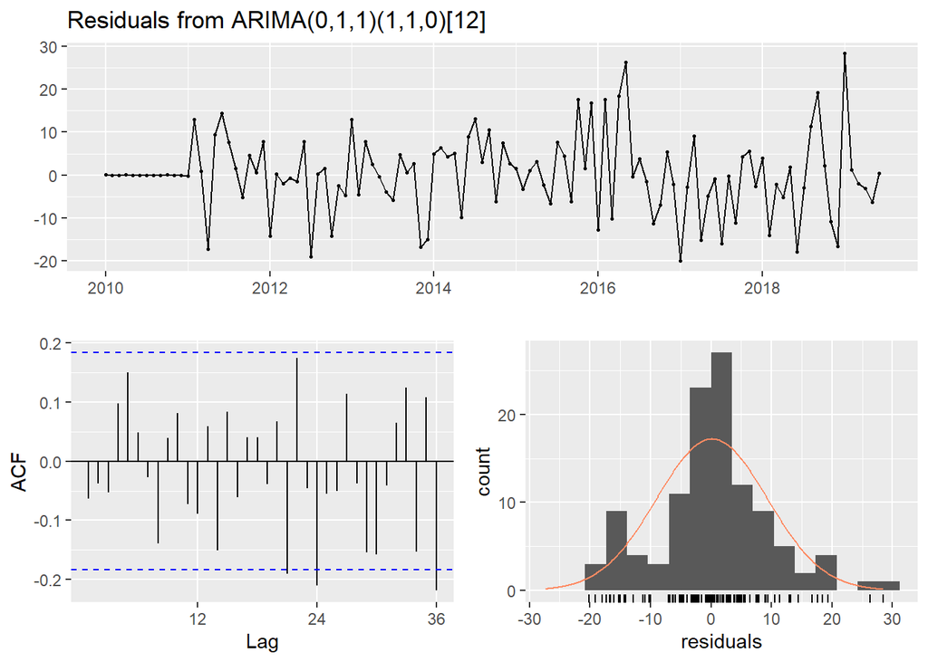

```
##
##  Ljung-Box test
##
## data:  Residuals from ARIMA(0,1,1)(1,1,0)[12]
## Q* = 26.395, df = 21, p-value = 0.1918
##
## Model df: 2.   Total lags used: 23
```

```r
checkresiduals(fit_arima)
```

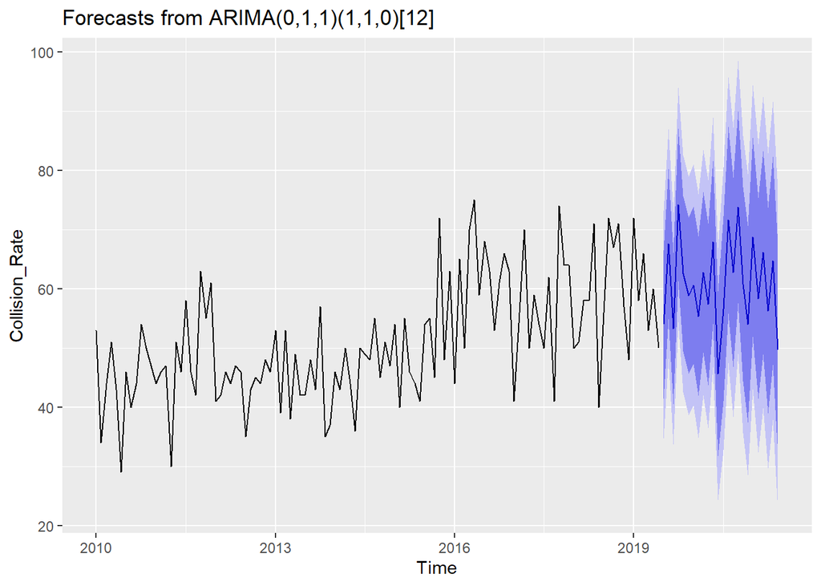

```r
#Forecast

Forecast <- forecast(fit_arima, h = 24)
autoplot(Forecast)
```